# QMSS: DataVisaulization_HW2

Tianyi Hu

2019-03-25

### Task 1. Data exploration

Before focusing on the spatial part of the data, let’s explore the basic patterns in the data.

#### a) Violation Code and Fine Amounts

Add the violation code descriptions and fine amounts to the data file. Provide a visual overview of the top 10 most common types of violations (feel free to group them into categories if reasonable). Compare how this ranking differs if we focus on the total amount of revenue generated.

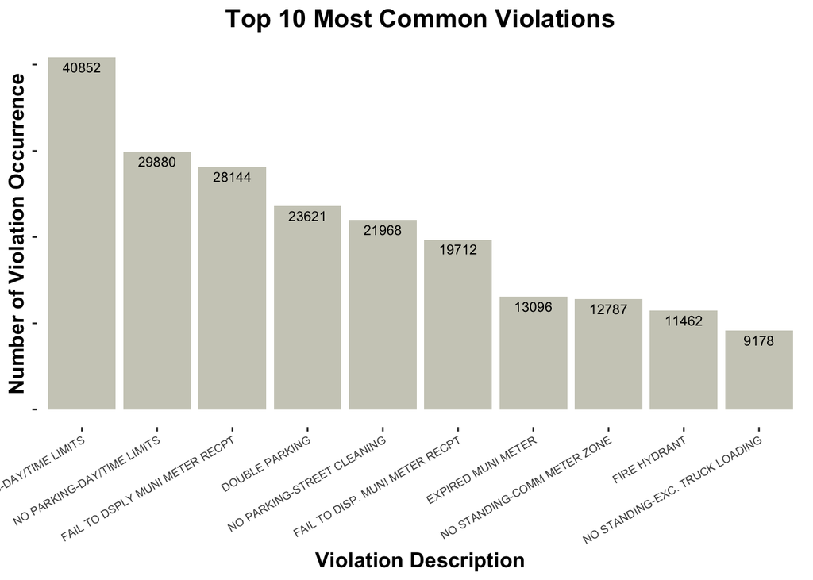

```r
#1a
library(readxl)
require(dplyr)
options(scipen = 200)
parkingNYC<-read.csv("parkingNYC_Jan2019.csv")
violation<-read_excel("parkingNYC_ParkingViolationCodes_Nov_2018.xlsx")
names(violation)[1]<-c("Violation.Code")
parkingNYC_violation=merge(parkingNYC,violation, by = "Violation.Code")
#count the number of each violation
violation_count <- parkingNYC_violation %>%
  mutate(number=1) %>%
  group_by(Violation.Code) %>%
  summarize(Times = length(number)) %>%
  arrange(desc(.$Times))

violation_type=merge(violation_count,violation, by = "Violation.Code")
violation_type=arrange(violation_type, desc(Times))
violation_type=head(violation_type, 10)
violation_type<- violation_type[,-c(4,5)]
names(violation_type)[3]<-c("Description")

#add up the total fine amount of each violation
names(parkingNYC_violation)[49]<-c("Fine_below96th")
names(parkingNYC_violation)[50]<-c("Fine_otherareas")

fine_total=merge(violation,violation_count, by = "Violation.Code")
names(fine_total)[3]<-c("Fine_below96th")
names(fine_total)[4]<-c("Fine_otherareas")
fine_total=mutate(fine_total,Fine_below96th_total=Fine_below96th * Times)
fine_total=mutate(fine_total,Fine_otherareas_total=Fine_otherareas * Times)
fine_total_1=arrange(fine_total,desc(Fine_below96th_total))
fine_total_below96th=head(fine_total_1, 10)
fine_total_below96th<- fine_total_below96th[,-c(3,4,5,7)]
fine_total_2=arrange(fine_total,desc(Fine_otherareas_total))
fine_total_otherareas=head(fine_total_2, 10)
fine_total_otherareas<- fine_total_otherareas[,-c(3,4,5,6)]
names(fine_total_below96th)[2]<-c("Description")
names(fine_total_otherareas)[2]<-c("Description")

#make bar chart
#install packages("ggplot2")
library(ggplot2)
#install.packages("plotly")
library("plotly")
#install.packages("ggthemes")
library(ggthemes)
#install.packages("hchart")

ggplot(violation_type, aes(x =reorder((Description),-Times), y = Times)) +
       geom_bar(stat = "identity",fill="ivory3") +
       geom_text(aes(label = Times), vjust = 1.5, colour = "black", position = position_dodge(.9), size = 3) +
       labs(x="Violation Description",y="Number of Violation Occurrence",title = "Top 10 Most Common Violations") +
       theme(panel.grid = element_blank(),panel.background = element_blank(),axis.text.y = element_blank() ) +
       theme(plot.title = element_text(hjust = 0.5),title=element_text(size=13, face= "bold", vjust=0.5, hjust=0.5),axis.text.x = element_text(size = 7,angle = 30,hjust = 1))
```

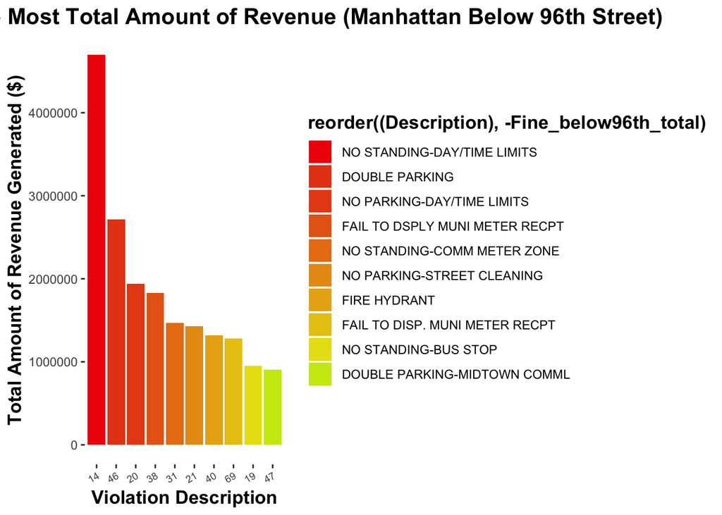

```r
ggplot(fine_total_below96th,aes(x =reorder((Violation.Code),-Fine_below96th_total), y = Fine_below96th_total)) +
  geom_bar(stat = "identity",aes(fill=reorder((Description), -Fine_below96th_total))) +
  labs(x="Violation Description",y="Total Amount of Revenue Generated ($)",title = "Top 10 Violations that Made Most Total Amount of Revenue (Manhattan Below 96th Street)") +
  theme(panel.grid = element_blank(),panel.background = element_blank()) +
  scale_fill_manual(values=c("#EF0707","#e84717","#e84e16","#e86615","#e87e14","#e89a13","#e8af12","#e8c711","#e8e011","#cbe811")) +
  theme(plot.title = element_text(hjust = 0.5),title=element_text(size=13, face= "bold", vjust=0.5, hjust=0.5),axis.text.x = element_text(size = 7,angle = 30,hjust = 1))
```

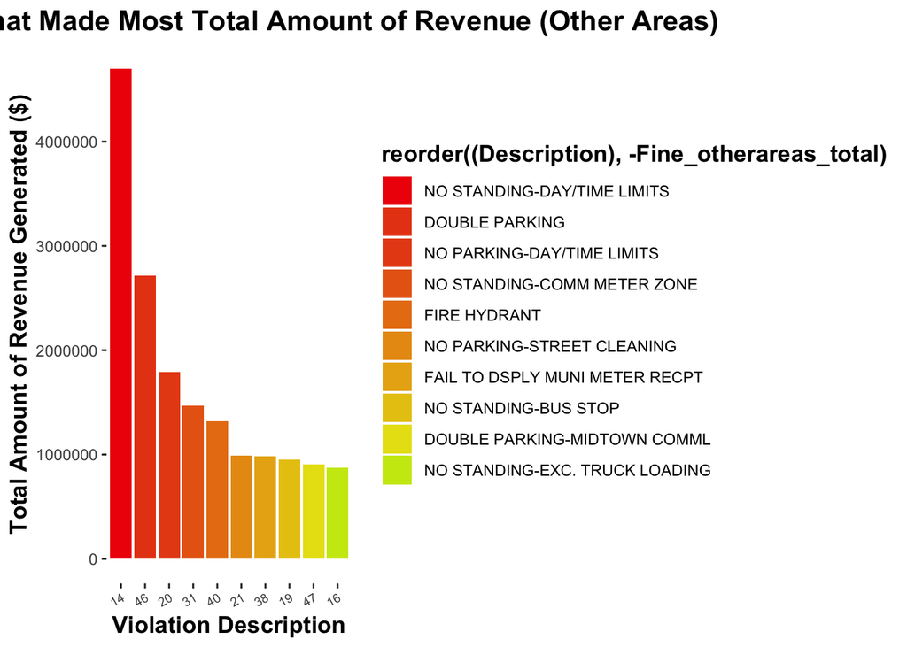

```r
ggplot(fine_total_otherareas,aes(x =reorder((Violation.Code),-Fine_otherareas_total), y = Fine_otherareas_total)) +
  geom_bar(stat = "identity",aes(fill=reorder((Description), -Fine_otherareas_total))) +
  labs(x="Violation Description",y="Total Amount of Revenue Generated ($)",title = "Top 10 Violations that Made Most Total Amount of Revenue (Other Areas)") +
  theme(panel.grid = element_blank(),panel.background = element_blank()) +
  scale_fill_manual(values=c("#EF0707","#e84717","#e84e16","#e86615","#e87e14","#e89a13","#e8af12","#e8c711","#e8e011","#cbe811")) +
  theme(plot.title = element_text(hjust = 0.5),title=element_text(size=13, face= "bold", vjust=0.5, hjust=0.5),axis.text.x = element_text(size = 7,angle = 30,hjust = 1))
```

#### b) Average amount of fine by vehicle

Compare the average amount of fine by vehicle color, vehicle year, and vehicle plate type [Hint: it is sufficient to restrict your attention to commercial (COM) and passenger (PAS) vehicles]? Briefly describe your findings.

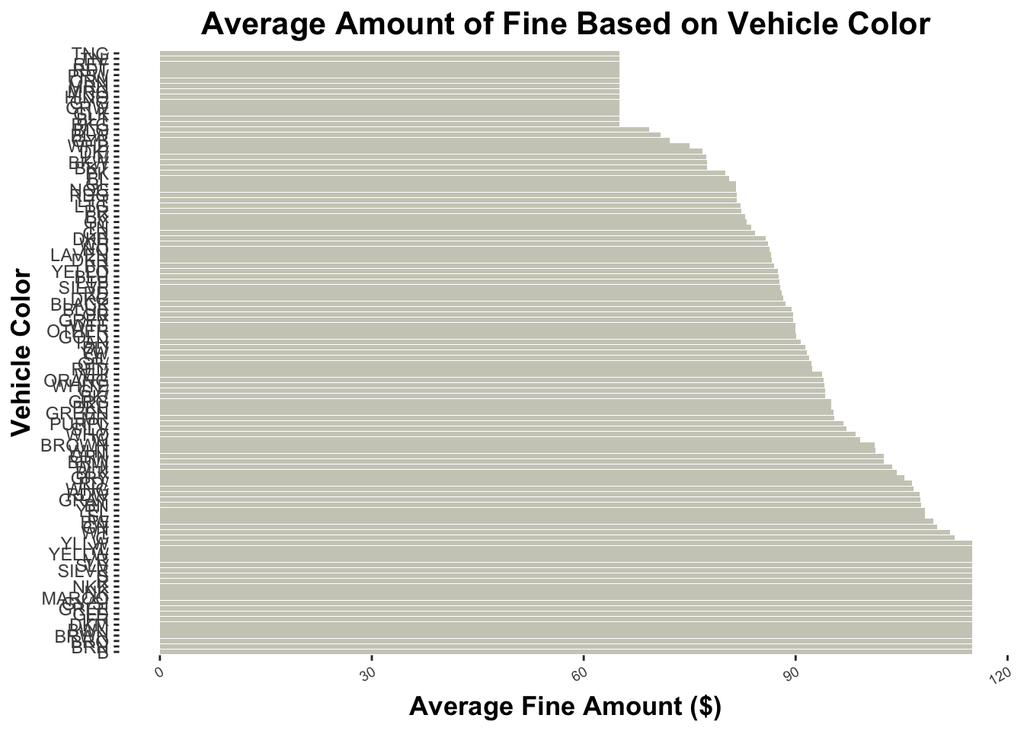

```r
#1b
violation_vehicle=parkingNYC_violation[,-c(2:4,6:33,35,37:48,50)]
violation_vehicle<-na.omit(violation_vehicle)
names(violation_vehicle)[2]<-c("PlateType")
names(violation_vehicle)[3]<-c("VehicleColor")
names(violation_vehicle)[4]<-c("VehicleYear")

violation_vehicle<- violation_vehicle%>%
  filter(PlateType == "PAS" | PlateType == "COM")


violation_vehicle_color<-violation_vehicle%>%
  mutate(number=1) %>%
  group_by(VehicleColor) %>%
  summarise(AverageFine=(sum(Fine_below96th)/length(number))  )
violation_vehicle_color=arrange(violation_vehicle_color,desc(AverageFine))


violation_vehicle_platetype<-violation_vehicle%>%
  mutate(number=1) %>%
  group_by(PlateType) %>%
  summarise(AverageFine=(sum(Fine_below96th)/length(number))  )

violation_vehicle_year<-violation_vehicle%>%
  mutate(number=1) %>%
  group_by(VehicleYear) %>%
  summarise(AverageFine=(sum(Fine_below96th)/length(number))  )
violation_vehicle_year<- violation_vehicle_year%>%
  filter(VehicleYear != "0" )
violation_vehicle_year=arrange(violation_vehicle_year,desc(AverageFine))


ggplot(violation_vehicle_color, aes(x =reorder((VehicleColor),-AverageFine), y = AverageFine)) +
  geom_bar(stat = "identity",fill="ivory3") +
  coord_flip()+
  labs(x="Vehicle Color",y="Average Fine Amount ($)",title = "Average Amount of Fine Based on Vehicle Color") +
  theme(panel.grid = element_blank(),panel.background = element_blank()) +
  theme(plot.title = element_text(hjust = 0.5),title=element_text(size=13, face= "bold", vjust=0.5, hjust=0.5),axis.text.x = element_text(size = 7,angle = 30,hjust = 1))
```

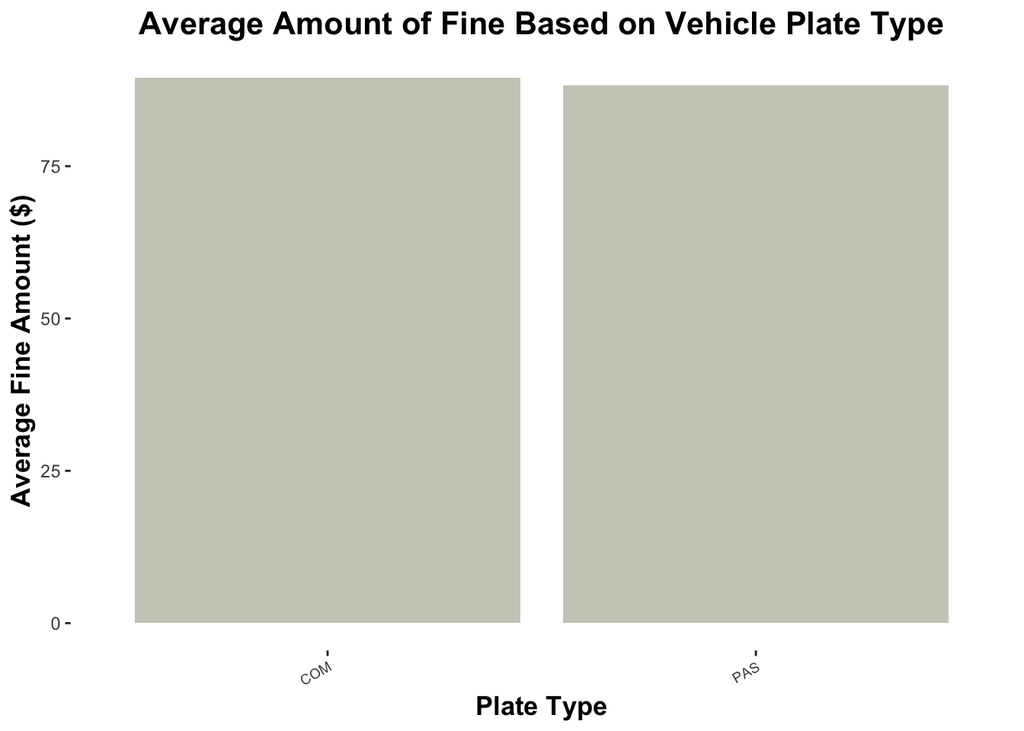

```r
ggplot(violation_vehicle_platetype, aes(x =reorder((PlateType),-AverageFine), y = AverageFine)) +
  geom_bar(stat = "identity",fill="ivory3") +
  labs(x="Plate Type",y="Average Fine Amount ($)",title = "Average Amount of Fine Based on Vehicle Plate Type") +
  theme(panel.grid = element_blank(),panel.background = element_blank()) +
  theme(plot.title = element_text(hjust = 0.5),title=element_text(size=13, face= "bold", vjust=0.5, hjust=0.5),axis.text.x = element_text(size = 7,angle = 30,hjust = 1))
```

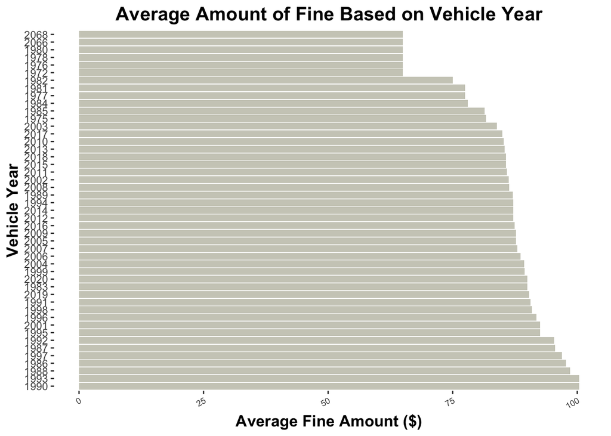

```r
ggplot(violation_vehicle_year, aes(x =reorder((VehicleYear),-AverageFine), y = AverageFine)) +
  geom_bar(stat = "identity",fill="ivory3") +
  coord_flip()+
  labs(x="Vehicle Year",y="Average Fine Amount ($)",title = "Average Amount of Fine Based on Vehicle Year") +
  theme(panel.grid = element_blank(),panel.background = element_blank()) +
  theme(plot.title = element_text(hjust = 0.5),title=element_text(size=13, face= "bold", vjust=0.5, hjust=0.5),axis.text.x = element_text(size = 7,angle = 30,hjust = 1))
```

### Task 2. Map by Precincts

Read in the shape files for the police precincts and remove all precincts outside of Manhattan.

#### a) Number of tickets, total fines, and average fines

Provide three maps that show choropleth maps of:

the total number of tickets the total amount of fines the average amount of fines

Briefly describe what you learn from these maps in comparison.

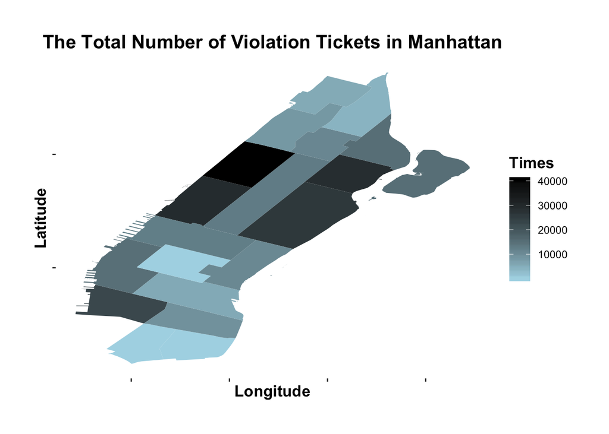

```r
#2a
names(parkingNYC_violation)[15]<-c('ViolationPrecinct')
ticket_count <- parkingNYC_violation %>%
  mutate(number=1) %>%
  group_by(ViolationPrecinct) %>%
  summarize(Times = length(number)) %>%
  arrange((.$ViolationPrecinct))

fine_total <- parkingNYC_violation%>%
  filter(ViolationPrecinct <= 32) %>%
  mutate(Fine=Fine_below96th)
fine_total_2 <- parkingNYC_violation%>%
  filter(ViolationPrecinct >32) %>%
  mutate(Fine=Fine_otherareas)
fine_total_1 <- fine_total%>%
  mutate(number=1) %>%
  group_by(ViolationPrecinct) %>%
  summarise(AverageFine=(sum(Fine)/length(number))  )
fine_total <- fine_total%>%
  mutate(number=1) %>%
  group_by(ViolationPrecinct) %>%
  summarise(TotalFine=sum(Fine))
fine_total=mutate(fine_total,id=1:23)
fine_total_1=mutate(fine_total_1,id=1:23)
ticket_count=mutate(ticket_count,id=1:43)

#install.packages("maptools")
library(maptools)
#install.packages("rgdal")
library(rgdal)
nyc_pp <- readOGR("nypp_19a/.","nypp")
# Let's keep only Manhattan
nyc_pp <- subset(nyc_pp, Precinct<=32)
#install.packages("tmap")
library(tmap)

nyc_pp <- spTransform(nyc_pp, CRS("+proj=longlat +datum=WGS84"))
nyc_pp <- fortify(nyc_pp)
map_nyc_pp=merge(nyc_pp,fine_total_1, by = "id")
map_nyc_pp_2=merge(nyc_pp,fine_total, by = "id")
map_ticket_count=merge(nyc_pp,ticket_count, by = "id")

names(map_nyc_pp_2)[c(2,3)] = c("x", "y")
names(map_nyc_pp)[c(2,3)] = c("x", "y")
names(map_ticket_count)[c(2,3)] = c("x", "y")

ggplot(map_ticket_count) + geom_map(aes(map_id = id, fill = Times), map = map_ticket_count) +
  expand_limits(map_ticket_count) +
  scale_fill_gradient(high = "black", low = "light blue") +
  labs(x='Longitude',y='Latitude',title='The Total Number of Violation Tickets in Manhattan')+
  theme(panel.grid = element_blank(),panel.background = element_blank(), axis.text.y = element_blank(),axis.text.x = element_blank()) +
  theme(plot.title = element_text(hjust = 0.5),title=element_text(size=13, face= "bold", vjust=0.5, hjust=0.5),plot.margin=unit(rep(2,4),'lines')  )
```

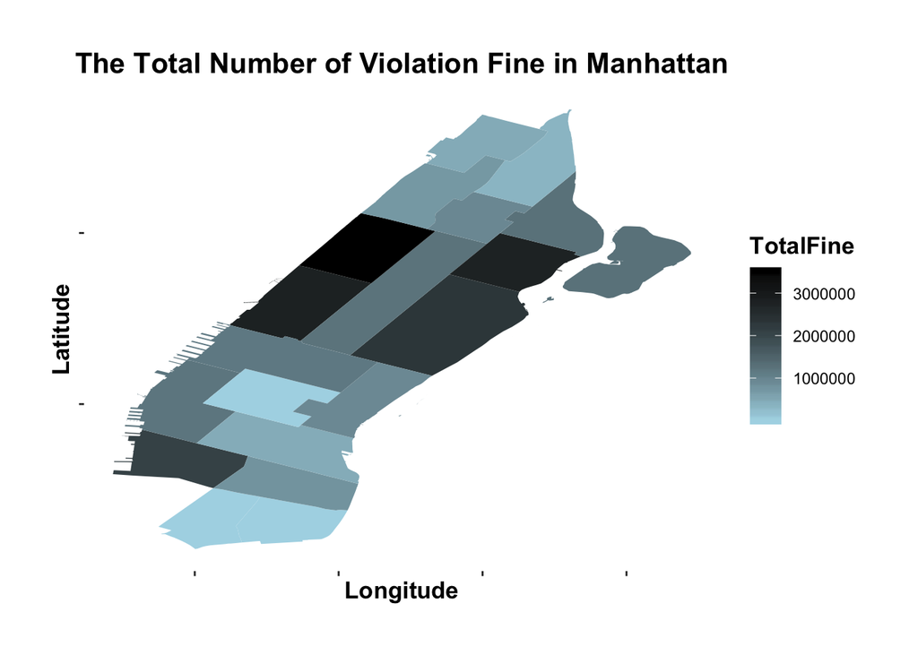

```r
ggplot(fine_total) + geom_map(aes(map_id = id, fill = TotalFine), map = map_nyc_pp_2) +
  expand_limits(map_nyc_pp_2) +
  scale_fill_gradient(high = "black", low = "light blue") +
  labs(x='Longitude',y='Latitude',title='The Total Number of Violation Fine in Manhattan')+
  theme(panel.grid = element_blank(),panel.background = element_blank(), axis.text.y = element_blank(),axis.text.x = element_blank()) +
  theme(plot.title = element_text(hjust = 0.5),title=element_text(size=13, face= "bold", vjust=0.5, hjust=0.5),plot.margin=unit(rep(2,4),'lines')  )
```

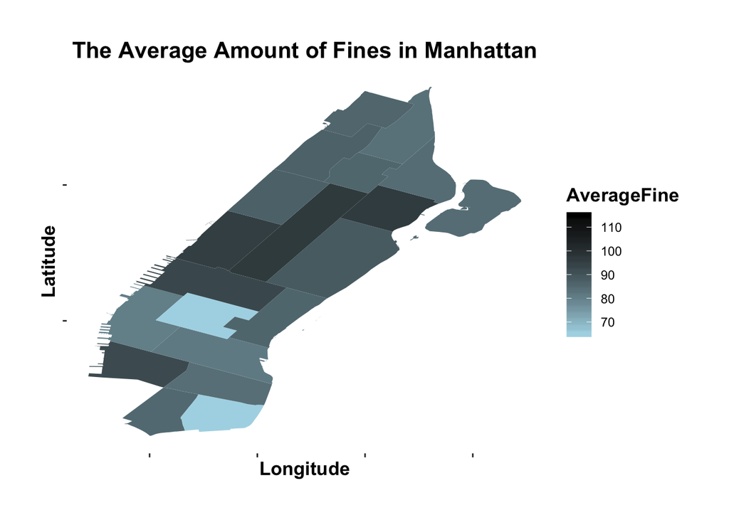

```r
ggplot(fine_total_1) + geom_map(aes(map_id = id, fill = AverageFine), map = map_nyc_pp) +
  expand_limits(map_nyc_pp) +
  scale_fill_gradient(high = "black", low = "light blue") +
  labs(x='Longitude',y='Latitude',title='The Average Amount of Fines in Manhattan')+
  theme(panel.grid = element_blank(),panel.background = element_blank(), axis.text.y = element_blank(),axis.text.x = element_blank()) +
  theme(plot.title = element_text(hjust = 0.5),title=element_text(size=13, face= "bold", vjust=0.5, hjust=0.5),plot.margin=unit(rep(2,4),'lines')  )
```

From the picture above, I could learn that the most number of violation tickets, the most total amount of fines, and the average amount of fines will be besides the Central Park.

#### b) Types of violations

Group the almost 100 types of ticket violations into a smaller set of 4-6 subgroups (where other should be the remainder of violations not included in other groups you defined). [Hint: No need to spend more than 5 minutes thinking about what the right grouping is.]. Provide choropleth maps for each of these subgroups to show where different types of violations are more or less common.

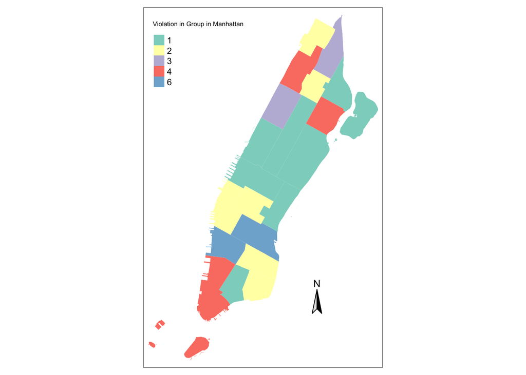

```r
#2b
names(violation)[3]<-c('Fine')
violation_group <- violation %>% mutate(
  Group = case_when(Violation.Code <15 ~"1",Violation.Code >=15 & Violation.Code<=22 ~ "2",Violation.Code>23&Violation.Code<=45~ "3",Violation.Code>45&Violation.Code<=65~ "4",Violation.Code>65&Violation.Code<=70~ "5",Violation.Code>70&Violation.Code<100~ "6"))
violation_count <- parkingNYC_violation %>%
  mutate(number=1) %>%
  group_by(Violation.Code) %>%
  summarize(Times = length(number)) %>%
  arrange(desc(.$Times))
names(violation_count)[1]<-c('VIOLATION CODE')
names(violation_group)[1]<-c('VIOLATION CODE')
names(parkingNYC_violation)[1]<-c('VIOLATION CODE')
violation_group=merge(violation_group,violation_count, by='VIOLATION CODE')
violation_group=mutate(violation_group, TotalFine=Fine*Times)
violation_group_test=merge(violation_group,parkingNYC_violation, by='VIOLATION CODE')
violation_group_test<-violation_group_test[,-c(3:4,6,8:20,22:56)]
violation_group_test_count<- violation_group_test %>%
  group_by(ViolationPrecinct,Group) %>%
  summarize(TotalFine=sum(TotalFine))
violation_group_test_count_2 <- violation_group_test_count%>%
  filter(ViolationPrecinct <29) %>%
  group_by(ViolationPrecinct,Group) %>%
  mutate(TotalFine=max(TotalFine))%>%
  ungroup()
violation_group_test_count_2 <- violation_group_test_count_2 %>%
  group_by(ViolationPrecinct) %>%
  filter(TotalFine==max(TotalFine)) %>%
  ungroup()
nyc_pp <- readOGR("nypp_19a/.","nypp")
nyc_pp <- subset(nyc_pp, Precinct<=32)
nyc_pp@data$group=violation_group_test_count_2$Group
library("ggmap")
tm_shape(nyc_pp)+tm_fill("group",title="Violation in Group in Manhattan")+
  tm_compass(position = c(.65, .15), color.light = "grey90")
```

### Task 3. Focus on the Upper East

Precinct 19 identifies the Upper East Side. The data currently does not provide latitude and longitude of the violation locations (and I am not sure what these street_code variables are for).

#### a) Ignoring fire hydrants

Restrict your data to parking violations related to fire hydrants (Violation Code = 40). Using the variables Street Name and House Number as well as the knowledge that these addresses are in the Upper East Side of Manhattan, geocode at least 500 addresses. Include a data table of these addresses and the latitude and longitude of these addresses in the output.

```r
#3a
library("tidyr")
Upeast_data <- parkingNYC%>%
  filter(Violation.Code == "40" & Violation.Precinct == "19")%>%
  arrange((.$Street.Name))%>%
  unite(address,House.Number,Street.Name)%>%
  head(600)
{for(i in 1:nrow(Upeast_data))
{
  # Print("Working...")
  result <- geocode(Upeast_data$address[i], output = "latlona", source = "google")
  Upeast_data$lon[i] <- as.numeric(result[1])
  Upeast_data$lat[i] <- as.numeric(result[2])
}
  }
Upeast_data_test<-Upeast_data[,-c(1:46)]
Upeast_data_test<-na.omit(Upeast_data_test)
names(Upeast_data_test)[1]<-c("Longitude")
names(Upeast_data_test)[2]<-c("Latitude")
names(Upeast_data)[47]<-c("Longitude")
names(Upeast_data)[48]<-c("Latitude")


{for(i in 1:nrow(Upeast_data_test))
{
  result <- revgeocode(c(Upeast_data_test$Longitude[i], Upeast_data_test$Latitude[i]), output="address")
  Upeast_data_test$address[i] <- as.character(result[1])
}
}
library(DT)
datatable(Upeast_data_test)
```

|  | Longitude | Latitude | address |
| --- | --- | --- | --- |
| 1 | -73.992041 | 40.738829 | 130 5th Ave, New York, NY 10011, USA |
| 2 | -105.052736 | 39.718158 | W 1st Ave &amp; Sheridan Blvd, Denver, CO 80219, USA |
| 3 | -73.992041 | 40.738829 | 130 5th Ave, New York, NY 10011, USA |
| 4 | -73.992041 | 40.738829 | 130 5th Ave, New York, NY 10011, USA |
| 6 | -73.992041 | 40.738829 | 130 5th Ave, New York, NY 10011, USA |
| 7 | -73.992041 | 40.738829 | 130 5th Ave, New York, NY 10011, USA |
| 8 | -105.052736 | 39.718158 | W 1st Ave &amp; Sheridan Blvd, Denver, CO 80219, USA |
| 9 | -73.9541443 | 40.769885 | 1448 1st Avenue, New York, NY 10021, USA |
| 10 | -88.8361283 | 41.3205445 | 1640 1st Ave, Ottawa, IL 61350, USA |
| 11 | -96.4143588 | 42.4739549 | 1615 1st Ave, South Sioux City, NE 68776, USA |

[output cut: 549 more lines]

#### b) Interactive map

Provide an interactive map of the violations you geocoded using leaflet. Provide at least three pieces of information on the parking ticket in a popup.

```r
#3b
Upeast_data=merge(Upeast_data_test,Upeast_data, by = c("Longitude","Latitude"))
Upeast_data<-unique(Upeast_data)
Upeast_data_test_2<-Upeast_data[,-c(14:49)]
Upeast_data_test_2=merge(Upeast_data_test_2,parkingNYC_violation, by = "Summons.Number")
library(devtools)
library(leaflet)
content <- paste("Plate ID:",Upeast_data_test_2$Plate.ID,"<br/>",
                 "Violation Code:",Upeast_data_test_2$`VIOLATION CODE`,"<br/>",
                 "Issue Date:",Upeast_data_test_2$Issue.Date,"<br/>")
leaflet(Upeast_data_test_2) %>%
  addTiles() %>%
  addCircles(popup = content)%>%
  setView(-73.96, 40.77, zoom = 14)
```

[interactive chart not shown]

#### c)

Using the vehicle Plate ID, identify repeat offenders (in the full dataset). Create another variable called luxury_car in which you identify luxury car brands using the Vehicle Make variable.

Start with the previous map. Distinguish the points by whether the car is a repeat offender and/or luxury car. Add a legend informing the user about the color scheme. Also make sure that the added information about the car type and repeat offender status is now contained in the popup information. Show this map.

```r
#3c
repeat_violation<-parkingNYC_violation %>%
  group_by(Plate.ID) %>%
  mutate(index = n()) %>%
  filter(index > 1) %>%
  ungroup()
repeat_violation_test<- repeat_violation%>%
  mutate(luxury_car = case_when(Vehicle.Make == "LEXUS" | Vehicle.Make == "TESLA"| Vehicle.Make == "LINCO" | Vehicle.Make == "BMW"~ 1,TRUE ~ 0))
repeat_violation_test_2<-merge(repeat_violation_test,Upeast_data_test_2,by="Summons.Number")
repeat_violation_test_2<-repeat_violation_test_2[,-c(4:5,7,9:33,35:51,56:114)]
repeat_violation_test_2<-repeat_violation_test_2[-c(73,221),]
library(devtools)
library(leaflet)
popup = paste("Plate ID:",repeat_violation_test_2$Plate.ID,"<br/>",
              "Issue Date:",repeat_violation_test_2$Issue.Date,"<br/>",
              "Vehicle Make:",repeat_violation_test_2$Vehicle.Make,"<br/>",
              "Vehicle Color:",repeat_violation_test_2$Vehicle.Color.x,"<br/>")
library(RColorBrewer)
pal = colorFactor("Set1", domain = repeat_violation_test_2$luxury_car)
color_Vehicle = pal(repeat_violation_test_2$luxury_car)
leaflet(Upeast_data_test_2) %>%
  addTiles() %>%
  addCircles(popup = popup,color=color_Vehicle)%>%
  setView(-73.96, 40.77, zoom = 15)%>%
  addLegend(pal=pal, value=~repeat_violation_test_2$luxury_car,title="Luxury Cars")
```

[interactive chart not shown]

#### d) Cluster

Add marker clustering, so that zooming in will reveal the individual locations but the zoomed out map only shows the clusters. Show the map with clusters.

```r
#3d
leaflet(Upeast_data_test_2) %>%
  addTiles() %>%
  setView(-73.96, 40.77, zoom = 14)%>%
  addLegend(pal=pal, value=~repeat_violation_test_2$luxury_car,title="Luxury Cars")%>%
  addMarkers(clusterOptions = markerClusterOptions(),popup=popup)
```

[interactive chart not shown]